# 1.1

```python
import pandas as pd
import matplotlib.pyplot as plt

# Load and preprocess data
data = pd.read_csv('merged_data_meghana.csv')  # Your data file
data['clm_from_dt'] = pd.to_datetime(data['clm_from_dt'], errors='coerce')
data['year'] = data['clm_from_dt'].dt.year

# Filter for the four products
products = ['J3010', 'J1885', 'J2250', 'J2704']
filtered_data = data[data['clm_line_hcpcs_cd'].isin(products)]

filtered_data = filtered_data[
    (filtered_data['clm_from_dt'].dt.year >= 2016) &
    (filtered_data['clm_from_dt'].dt.year <= 2018)]

# Calculate metrics
metrics = filtered_data.groupby(['year', 'clm_line_hcpcs_cd']).agg(
    claims=('cur_clm_uniq_id', 'count'),
    patients=('bene_mbi_id', 'nunique'),
    hcps=('fac_prvdr_npi_num', 'nunique')
).reset_index()

# Normalize to percentages for stacked bar charts
metrics['claims_percentage'] = metrics.groupby('year')['claims'].transform(lambda x: x / x.sum() * 100)
metrics['patients_percentage'] = metrics.groupby('year')['patients'].transform(lambda x: x / x.sum() * 100)
metrics['hcps_percentage'] = metrics.groupby('year')['hcps'].transform(lambda x: x / x.sum() * 100)
```

```python
# Function to plot 100% stacked bar chart with numbers
def plot_stacked_bar_with_numbers(df, value_col, title, ylabel):
    pivot_df = df.pivot(index='year', columns='clm_line_hcpcs_cd', values=value_col)
    ax = pivot_df.plot(kind='bar', stacked=True, figsize=(10, 6), colormap='tab10')

    # Adding numbers on top of bars
    for i, bars in enumerate(ax.containers):
        for bar in bars:
            height = bar.get_height()
            if height > 0:  # Only annotate non-zero bars
                ax.text(
                    bar.get_x() + bar.get_width() / 2,  # X-coordinate (center of the bar)
                    bar.get_y() + height / 2,  # Y-coordinate (middle of the bar)
                    f'{height:.1f}%',  # Text (formatted to 1 decimal place)
                    ha='center', va='center', fontsize=8, color='black'
                )

    plt.title(title)
    plt.xlabel('Year')
    plt.ylabel(ylabel)
    plt.legend(title='Product', bbox_to_anchor=(1.05, 1), loc='upper left')
    plt.tight_layout()
    plt.show()
```

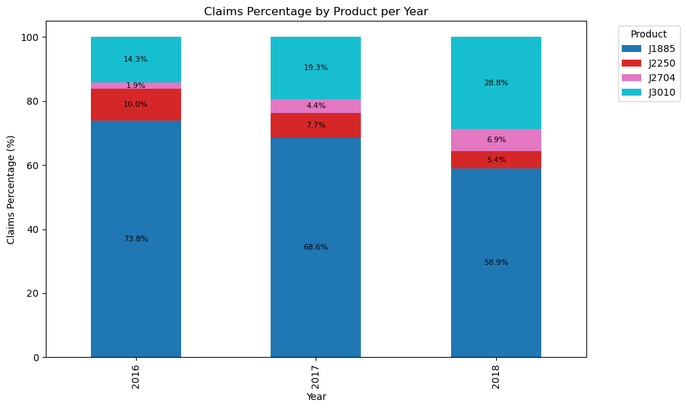

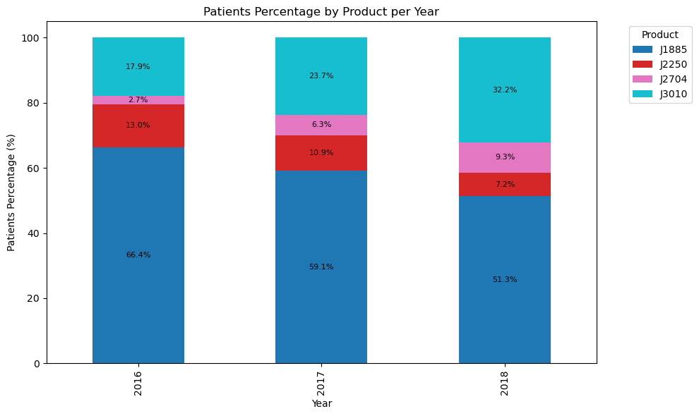

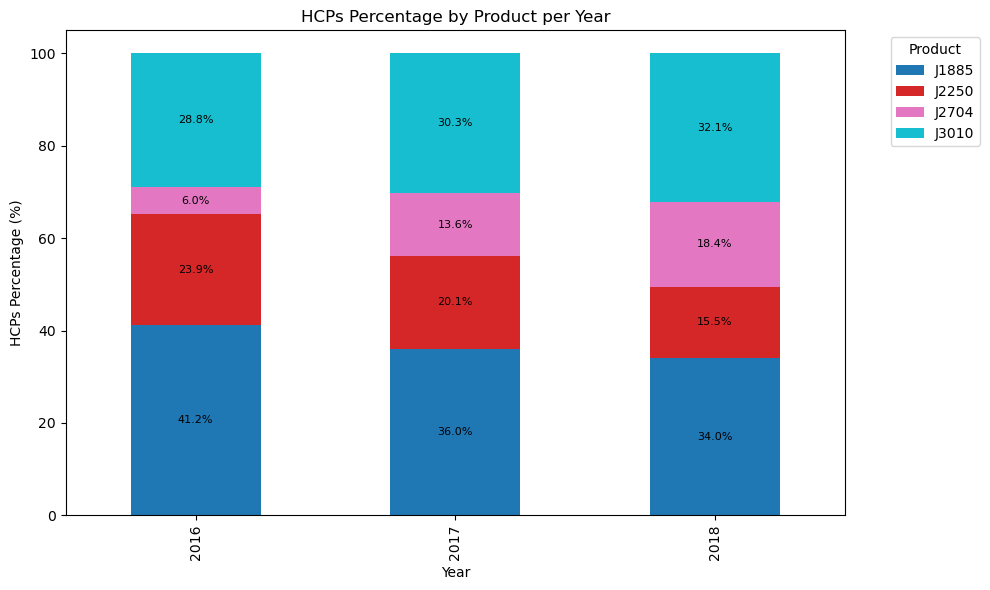

```python
# Plot Claims Percentage
plot_stacked_bar_with_numbers(metrics, 'claims_percentage', 'Claims Percentage by Product per Year', 'Claims Percentage (%)')

# Plot Patients Percentage
plot_stacked_bar_with_numbers(metrics, 'patients_percentage', 'Patients Percentage by Product per Year', 'Patients Percentage (%)')

# Plot HCPs Percentage
plot_stacked_bar_with_numbers(metrics, 'hcps_percentage', 'HCPs Percentage by Product per Year', 'HCPs Percentage (%)')
```

### Observations from the Visuals

#### **Claims Percentage (First Chart)**

1. **Product 1 (J1885)**:
   - Declined consistently over three years from **73.8% in 2016 to 58.9% in 2018**.
   - This decline reflects significant market erosion, likely due to competition from Product 3 and a lack of competitive innovation.
2. **Product 2 (J2250)**:
   - Sharply declining market share, from **10.0% in 2016 to 5.4% in 2018**.
   - It is clearly underperforming and failing to capture HCPs or patient interest.
3. **Product 3 (J3010)**:
   - Aggressively gained market share, from **14.3% in 2016 to 28.8% in 2018**.
   - This trend highlights its appeal to both HCPs and patients as an effective alternative.
4. **Product 4 (J2704)**:
   - Gradual growth from **1.9% in 2016 to 6.9% in 2018**, indicating a small but consistent gain in niche markets.

#### **Patients Percentage (Second Chart)**

1. **Product 1 (J1885)**:
   - Dropped from **66.4% in 2016 to 51.3% in 2018**.
   - This decline shows that fewer patients are being treated with Product 1, reinforcing the shift to competitors.
2. **Product 2 (J2250)**:
   - Declined significantly, from **13.0% in 2016 to 7.2% in 2018**.
   - Struggling to attract patients, suggesting low perceived efficacy or adoption barriers.
3. **Product 3 (J3010)**:
   - Gained a substantial share, from **17.9% in 2016 to 32.2% in 2018**.
   - Evident patient preference, likely driven by superior efficacy or ease of administration.
4. **Product 4 (J2704)**:
   - Growth from **2.7% in 2016 to 9.3% in 2018**.
   - Indicates increasing popularity among specific patient segments.

#### **HCPs Percentage (Third Chart)**

1. **Product 1 (J1885)**:
   - Declined from **41.2% in 2016 to 34.0% in 2018**.
   - Shows that fewer HCPs are prescribing Product 1, likely shifting to Product 3 or 4.
2. **Product 2 (J2250)**:
   - Declined from **23.9% in 2016 to 15.5% in 2018**.
   - Losing traction among HCPs, reflecting weak market positioning.
3. **Product 3 (J3010)**:
   - Consistently grew from **28.8% in 2016 to 32.1% in 2018**.
   - Shows strong adoption by HCPs, aligning with the rise in patient and claim percentages.
4. **Product 4 (J2704)**:
   - Increased from **6.0% in 2016 to 18.4% in 2018**.
   - Rapid growth, indicating that HCPs are increasingly considering it as a viable alternative.

### **Strategy to Increase Market Share for Product 2**

#### **1. Reposition Product 2 (J2250)**

- **Unique Selling Proposition (USP)**:
  - Market Product 2 as the **preferred choice for sedation in high-risk or time-sensitive procedures**.
  - Highlight specific clinical advantages (e.g., smoother induction, fewer side effects) over Product 3 and Product 4.
- **Specialized Targeting**:
  - Focus on niche markets such as **pediatric anesthesia** or **preoperative sedation**, where Product 2 could outperform competitors.

#### **2. Increase Claims Percentage**

- **Target High-Volume HCPs**:
  - Identify HCPs or facilities generating the most claims for Products 1 and 3.
  - Provide these HCPs with personalized discounts, volume rebates, or promotional bundles for using Product 2.
- **Flexible Pricing**:
  - Aggressively reduce the price of Product 2 in competitive regions to undercut Product 3.
  - Offer tiered pricing that rewards higher claims volume for Product 2.
- **Claims Incentive Programs**:
  - Launch loyalty programs for HCPs, rewarding those who maintain or increase their claims percentage for Product 2.
- **Integrated Bundling**:
  - Bundle Product 2 with other complementary anesthesia solutions (e.g., pain management drugs) to drive its adoption.

#### **3. Increase HCP Adoption**

- **Education and Training**:
  - Conduct workshops and webinars emphasizing Product 2’s benefits, safety, and ease of use.
  - Compare it directly with Product 3 to highlight areas where it excels (e.g., cost-effectiveness, patient outcomes).
- **Target New HCP Segments**:
  - Expand marketing efforts to smaller or mid-tier hospitals and surgical centers where Product 3 dominates.
  - Incentivize early adopters of Product 2 to act as champions within their networks.
- **KOL Advocacy**:
  - Partner with key opinion leaders (KOLs) to advocate for Product 2’s usage, leveraging their influence to drive HCP adoption.
- **Data-Driven Targeting**:
  - Use analytics to identify HCPs already prescribing Products 1 and 3 but not Product 2, and tailor outreach efforts to convert them.

#### **4. Increase Patient Utilization**

- **Highlight Patient-Centric Benefits**:
  - Market Product 2’s patient-friendly profile (e.g., smoother recovery, minimal side effects).
  - Collaborate with hospitals to promote Product 2’s inclusion in pre-surgical packages.
- **Direct Patient Outreach**:
  - Develop patient-facing marketing materials that highlight the comfort and reliability of Product 2 during procedures.
- **Expand Use Cases**:
  - Encourage HCPs to use Product 2 for a broader range of procedures by demonstrating its versatility and efficacy in real-world scenarios.

#### **5. Competitive Positioning Against Product 3**

- **Direct Comparative Campaigns**:
  - Highlight any deficiencies or gaps in Product 3’s safety profile, efficacy, or pricing.
  - Use real-world data to demonstrate Product 2’s superiority in specific areas like recovery time or cost-effectiveness.
- **Addressing Pricing Parity**:
  - Ensure Product 2 is priced competitively with Product 3, even if this requires temporary margin cuts.

#### **6. Monitor and Optimize**

- **Track Key Metrics**:
  - Closely monitor changes in claims percentage, HCP adoption, and patient numbers for Product 2.
  - Focus on metrics like "claims per HCP" and "patients per HCP" to identify progress in key markets.
- **Iterative Adjustments**:
  - Continuously refine messaging, pricing, and incentives based on market feedback and competitive responses.

### **Specific Goals**

1. **Claims Percentage**:
   - Increase claims percentage for Product 2 by **targeting HCPs and facilities with tailored discounts and loyalty rewards**.
   - Aim for a **10-15% increase in claims volume** year-over-year in competitive regions.
2. **HCP Engagement**:
   - Boost the number of HCPs prescribing Product 2 by **targeting high-volume prescribers** of Product 1 and 3 with personalized incentives.
   - Achieve a **20% growth in HCP adoption** over the next two years.
3. **Patient Utilization**:
   - Drive a **15% increase in patients per HCP** using Product 2 through education campaigns and expanded use cases.